# Analysis of wild sea otter gingival communities

Natasha Dudek

04/12/2018

The oral microbiota has important implications for health, having been linked in humans to diverse diseases ranging from rheumatoid arthritis to adverse pregnancy outcomes (Lu et al., 2019). Here we will investigate variation in bacterial community composition and structure in the gingival microbiotas of wild sea otters.

Note: the clustering portion of this analysis is based on that done in DiGiulio, D.B., et al. “Temporal and spatial variation of the human microbiota during pregnancy.” Proceedings of the National Academy of Sciences 112.35 (2015): 11060-11065.

Set paths + working directory and load phyloseq object (wild sea otters lane)

```r
#path <- file.path("/Users", "path", "to", "dir", fsep="/")
path <- file.path("/Users", "natasha", "Desktop", "sea_otters", fsep="/")
setwd(path)
getwd()
```

```
## [1] "/Users/natasha/Desktop/sea_otters"
```

```r
physeq <- readRDS("physeq_lane1.rds")
```

Load libraries

```r
library("cluster"); packageVersion("cluster") # used for clustering samples
```

```
## [1] '2.1.0'
```

```r
library("DESeq2"); packageVersion("DESeq2") # used for differential abundance analysis
```

```
## [1] '1.24.0'
```

```r
library("dunn.test"); packageVersion("dunn.test") # needed to perform dunn test
```

```
## [1] '1.3.5'
```

```r
library("ellipse"); packageVersion("ellipse") # needed to draw confidence ellipses
```

```
## [1] '0.4.2'
```

```r
library("factoextra"); packageVersion("factoextra") # used for gap statistic calculations
```

```
## [1] '1.0.7'
```

```r
library("ggplot2"); packageVersion("ggplot2")
```

```
## [1] '3.3.2'
```

```r
library("grid"); packageVersion("grid") # needed to plot heatmap
```

```
## [1] '3.6.1'
```

```r
library("ggsignif"); packageVersion("ggsignif") # needed to add significance bars on alpha diversity figure
```

```
## [1] '0.6.0'
```

```r
library("phyloseq"); packageVersion("phyloseq")
```

```
## [1] '1.28.0'
```

```r
library("vegan"); packageVersion("vegan") # needed to get eigenvalues from RDA (plot axes proportional to variance explained)
```

```
## [1] '2.5.6'
```

ggplot2 package theme set

```r
theme_set(theme_bw())
```

Retain only wild sea otter gingival samples No duplicate samples per individual sea otter  
Remove any ASVs with zero count across all samples

```r
physeq <- subset_samples(physeq, facility == "CDFW")
physeq <- subset_samples(physeq, duplicate_capture == "no")
ps_gingival_orig <- subset_samples(physeq, sample_type == "oral")
ps_gingival_orig = filter_taxa(ps_gingival_orig, function(x) sum(x) > 0, TRUE)
```

Transform the data to be proportions (this is ok while we are not doing differential abundance analysis)

```r
ps_gingival <- transform_sample_counts(ps_gingival_orig, function(x) x/sum(x))
```

## K-mediods clustering analysis

We will begin by investigating whether there is some kind of sturcture in the gingival bacterial communities. This will be done using the k-mediods clustering, which is an unsupervised machine learning algorithm.

To calculate distances between communities, we will use the Bray-Curtis dissimilarity metric. This metric was selected because:

1. We don’t know if closely related strains may be having an effect -> choose a non-phylogenetically informed metric.
2. If two sets of samples both have species A, but in one set relative abundance is usually 1% and in the other it’s usually 99%, that information is significant -> choose a metric that uses relative abundance

First, calculate Bray-Curtis dissimilarity.

```r
braydist <- phyloseq::distance(ps_gingival, method="bray")
ord = ordinate(ps_gingival, method = "MDS", distance = braydist)
```

Now we want to retain only the most significant dimensions by choosing only the most significant eigenvalues. This will reduce noise in the dataset. We will start by plotting the eigenvalues.

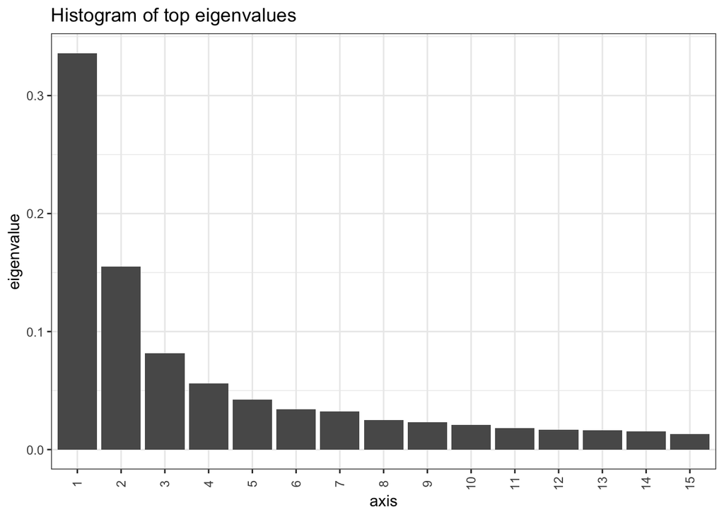

```r
plot_scree(ord) + xlim(as.character(seq(1,15))) + ggtitle("Histogram of top eigenvalues")
```

The first two or three look significant, but after that it’s hard to tell. We will plot a histogram of all eigenvalues to get a better idea of where to draw the cutoff.

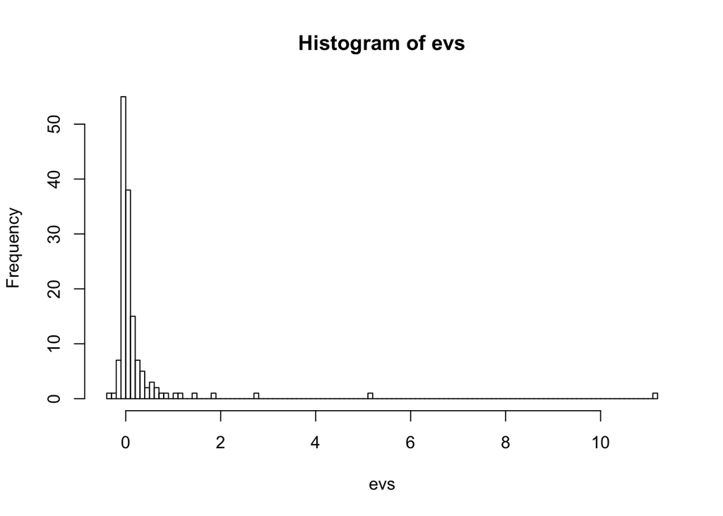

```r
evs <- ord$value$Eigenvalues
h_all <- hist(evs, 100)
```

We will proceed forwards using eigenvalues 1-5. This gives us 5 dimensions for MDS.

```r
NDIM <- 5
```

Now we need to determine the number of clusters we will use for k-mediods clustering. This will be done using the gap statistic and the selection criteria proposed by Tibshirani et al (2001)

```r
x <- ord$vectors[,1:NDIM]
pamPCoA = function(x, k) {
    list(cluster = pam(x[,1:2], k, cluster.only = TRUE))
}
set.seed(04122018) # today's date
gap_stat = clusGap(x, FUN = pamPCoA, K.max = 10, B = 100)
```

```
## Clustering k = 1,2,..., K.max (= 10): .. done
## Bootstrapping, b = 1,2,..., B (= 100)  [one "." per sample]:
## .................................................. 50
## .................................................. 100
```

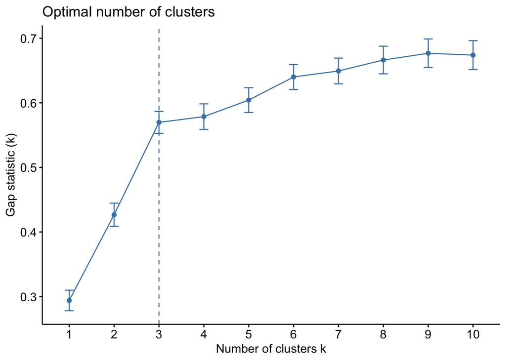

```r
fviz_gap_stat(gap_stat, maxSE = list(method = "Tibs2001SEmax"))
```

At k = 3 we see an elbow. We will use 3 clusters moving forwards.

Let’s run the k-mediods clustering algorithm.

```r
K <- 3
x <- ord$vectors[,1:NDIM]
clust <- as.factor(pam(x, k=K, cluster.only=T))
sample_data(ps_gingival)$CP <- clust
CPs <- as.character(seq(K))
```

Save identified CPs in the phyloseq “ps_gingival” and “ps_gingival_orig” objects for later use.

```r
sample_data(ps_gingival)$CP <- clust
sample_data(ps_gingival_orig)$CP <- clust
write.csv(sample_data(ps_gingival_orig), file = "gingival_cps.csv")
```

Now let’s visualize the clustering results with an MDA ordination.

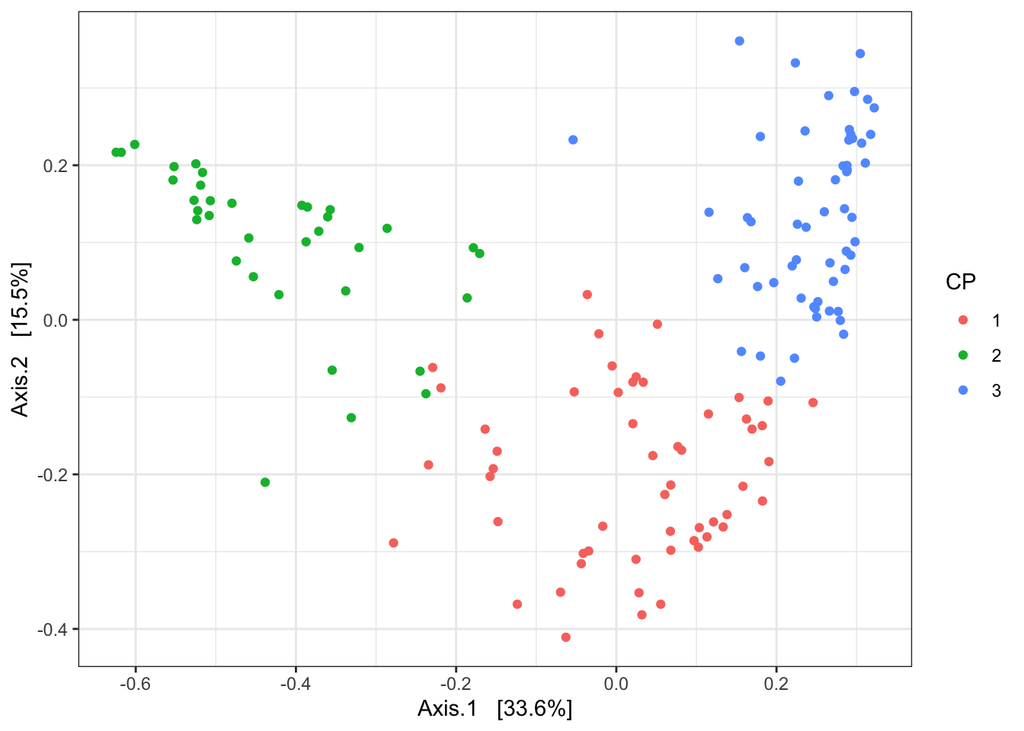

```r
CPColors <- c("#A7A7A7","dodgerblue","firebrick")
names(CPColors) <- CPs
CPColorScale <- scale_colour_manual(name = "CP", values = CPColors[1:3])
CPFillScale <- scale_fill_manual(name = "CP", values = CPColors[1:3])
plot_ordination(ps_gingival, ord, color="CP")
```

We see three distinct clusters which correspond well with the k-mediods analysis. We will refer to these as Community Profiles, or CPs, from here on.

## Perform redundancy analysis (RDA)

Note that RDA is the canonical version of PCA.

When performing and visualizing results, we will make sure to scales axes to the proportion of variance explained.

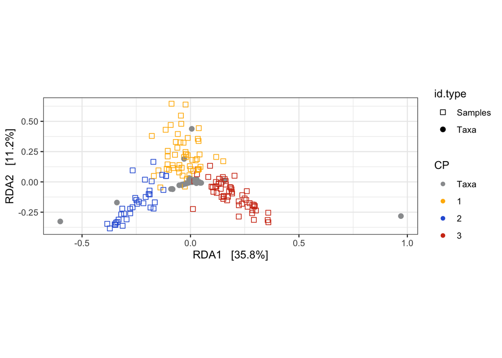

```r
#Perform ordination by community profile
ps_gingival.ord <- ordinate(ps_gingival, "RDA", "bray", formula=ps_gingival~CP)
evals <- eigenvals(ps_gingival.ord)
#Plot the CP ordination and add biplot with taxa, scale axes by magnitude of variance explained
p = plot_ordination(ps_gingival, ps_gingival.ord, type="biplot", color="CP", shape = "id.type") +
    coord_fixed(sqrt(evals[2] / evals[1]))
#p = plot_ordination(ps_gingival, ps_gingival.ord, type="biplot", color="CP", shape="id.type", label="Genus")
# Adjust aesthetic parameters of ordination
p = p +  scale_shape_manual(values=c(16,17,18,15)) +
    scale_size_manual(values=c(2,2,2,2)) +
    # grey (taxa), yellow (CP1), blue (CP2), red (CP3)
    scale_color_manual(values=c("#9a9c9e","#ffb600","#2d60d8","#d13917")) +
    scale_shape_manual(values=c(0, 19))
plot(p)
```

```r
ggsave('FigS2A.pdf', plot = p)
```

## Compare alpha diversity of different CPs

Perform Kruskal-Wallis test to determine whether there is any statistically significant different in alpha diversity between the three CPs (note: this is a non-parametric test).

Note: We will use ps_gingival_orig, which raw count data (has not been transformed).

```r
alphaSimpson = (estimate_richness(ps_gingival_orig, measures="Simpson"))
alpha.stats <- cbind(alphaSimpson, sample_data(ps_gingival_orig))
kruskal.test(Simpson~CP, data = alpha.stats)
```

```
##
##  Kruskal-Wallis rank sum test
##
## data:  Simpson by CP
## Kruskal-Wallis chi-squared = 43.501, df = 2, p-value = 3.58e-10
```

```r
dunn.test(alpha.stats$Simpson, alpha.stats$CP, method="bonferroni")
```

```
##   Kruskal-Wallis rank sum test
##
## data: x and group
## Kruskal-Wallis chi-squared = 43.501, df = 2, p-value = 0
##
##
##                            Comparison of x by group
##                                  (Bonferroni)
## Col Mean-|
## Row Mean |          1          2
## ---------+----------------------
##        2 |   5.649801
##          |    0.0000*
##        3 |   5.571355  -0.758460
##          |    0.0000*     0.6723
##
## alpha = 0.05
## Reject Ho if p <= alpha/2
```

CP1 is significantly different from CPs 2 & 3, which are not significantly different from one another

Now plot.

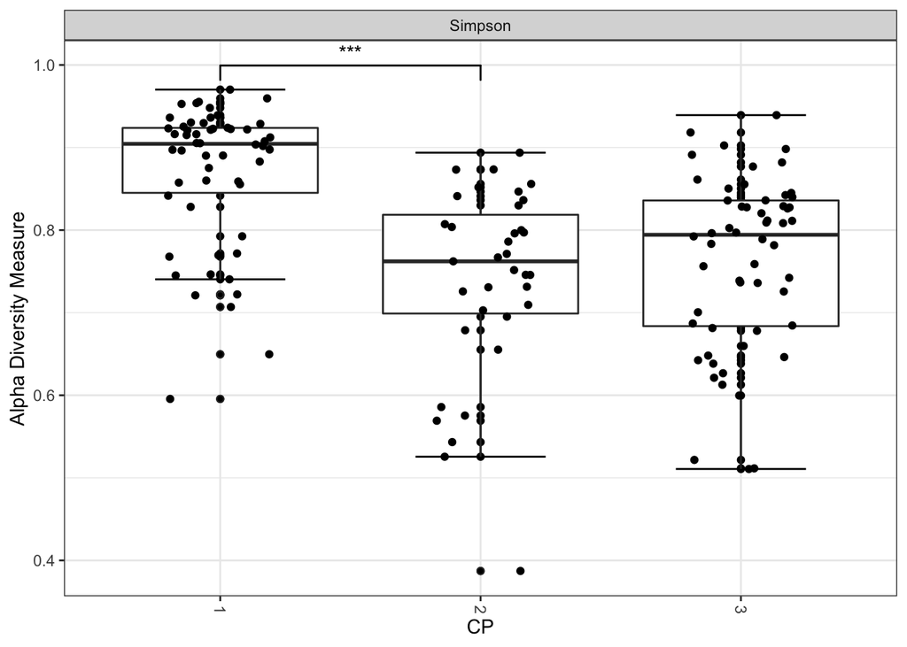

```r
p = plot_richness(ps_gingival_orig, measures="Simpson", x="CP")+
    stat_boxplot(geom='errorbar', linetype=1, width=0.5)+  #whiskers
    geom_boxplot(outlier.shape=1)  + geom_jitter(width = 0.2) +
    geom_signif(comparisons = list(c("1", "2")),
              map_signif_level=TRUE) +
    geom_signif(comparicdsons = list(c("1", "3")),
            map_signif_level=TRUE)
plot(p)
```

## Which ASVs are differentially abundant between CPs?

We will use the data in ps_gingival_orig, as it is raw count data (not transformed!). We will order by adjusted p-value and remove entries with an NA value.

```r
diagdds = phyloseq_to_deseq2(ps_gingival_orig, ~ CP)
diagdds = DESeq(diagdds, test="Wald", fitType="parametric")
```

```
## -- replacing outliers and refitting for 1369 genes
## -- DESeq argument 'minReplicatesForReplace' = 7
## -- original counts are preserved in counts(dds)
```

```r
res = results(diagdds, cooksCutoff = FALSE)
alpha = 0.05
sigtab = res[which(res$padj < alpha), ]
sigtab = cbind(as(sigtab, "data.frame"), as(tax_table(ps_gingival_orig)[rownames(sigtab), ], "matrix"))
write.csv(sigtab, file = "deseq2_gingivalCPs.csv")
dim(sigtab)
```

```
## [1] 42 13
```

Now plot the results of DESeq2

Note: the visualization is done at genus level rather than ASV / species because only two are differentially abundant ASVs are identified down to the level of species.

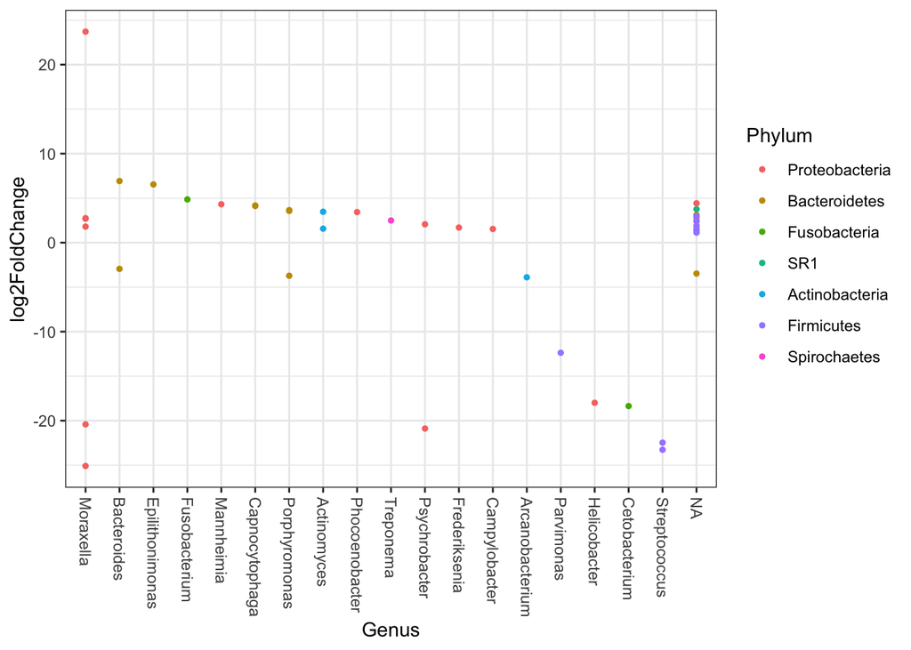

```r
scale_fill_discrete <- function(palname = "Set1", ...) {
    scale_fill_brewer(palette = palname, ...)
}
# Phylum order
x = tapply(sigtab$log2FoldChange, sigtab$Phylum, function(x) max(x))
x = sort(x, TRUE)
sigtab$Phylum = factor(as.character(sigtab$Phylum), levels=names(x))
# Genus order
x = tapply(sigtab$log2FoldChange, sigtab$Genus, function(x) max(x))
x = sort(x, TRUE)
sigtab$Genus = factor(as.character(sigtab$Genus), levels=names(x))
p = ggplot(sigtab, aes(x=Genus, y=log2FoldChange, color=Phylum)) + geom_point(size=1) +
  theme(axis.text.x = element_text(angle = -90, hjust = 0, vjust=0.5))

plot(p)
```

```r
ggsave('FigS2B.pdf', plot = p)
```

## Save list of ASVs and relative abundance in each CP

This will be used to ask which ASV tends to be the most abundant in samples in each CP

```r
cp1_ps <- subset_samples(ps_gingival_orig, CP == "1")
cp2_ps <- subset_samples(ps_gingival_orig, CP == "2")
cp3_ps <- subset_samples(ps_gingival_orig, CP == "3")
write.csv(otu_table(cp1_ps), file = "cp1_asvs.csv")
write.csv(otu_table(cp2_ps), file = "cp2_asvs.csv")
write.csv(otu_table(cp3_ps), file = "cp3_asvs.csv")
```

## Correlation between CP and associated metadata

Now that we have evidence for different CPs, a natural question is what causes them? Here we will probe whether there is a correlation between CP and time or location

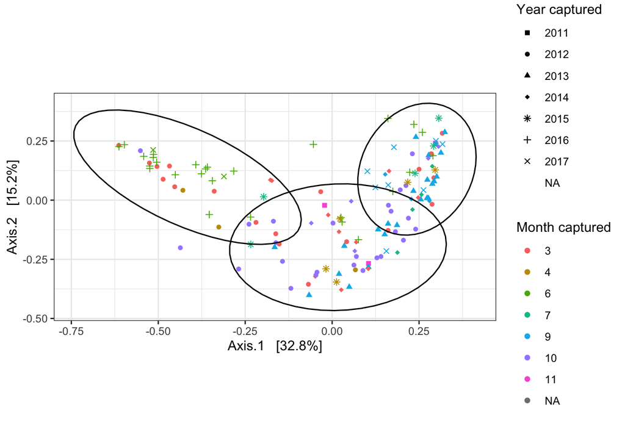

```r
sample_data(ps_gingival_orig)$year_captured <- factor(
  sample_data(ps_gingival_orig)$year_captured,
  levels = c("2011", "2012", "2013", "2014", "2015","2016","2017")
)
sample_data(ps_gingival_orig)$month_captured <- factor(
  sample_data(ps_gingival_orig)$month_captured,
  levels = c("1", "2", "3", "4", "5","6","7","8","9","10","11","12")
)
year_captured <- as.factor(sample_data(ps_gingival_orig)$year_captured)
# Ordinate
gingival_pcoa <- ordinate(
  physeq = ps_gingival_orig,
  method = "PCoA",
  distance = "bray"
)
evals <- gingival_pcoa$values$Eigenvalues
# Plot
p = plot_ordination(physeq = ps_gingival_orig, ordination = gingival_pcoa, color = "month_captured", shape = "year_captured") +
  coord_fixed(sqrt(evals[2] / evals[1])) +
  labs(col = "Month captured", shape = "Year captured") +
  scale_shape_manual(values=c(15,16,17,18,8,3,4,8))
# add 95% confidence ellipse
p = p + theme_bw() + stat_ellipse(geom = "polygon",level=0.95, type="norm",alpha=0,color="black", aes(group=CP))
plot(p)
```

By eye it looks like there may be a correlation between month captured and CP. Now evaluate whether this is statistically supported.

First create a matrix showing the frequency of CPs by month

```r
cst_mo_freqs <- table(sample_data(ps_gingival_orig)$month_captured, sample_data(ps_gingival_orig)$CP)
```

Now perform Fisher’s exact test.  
(Note: cannot do a Chi-squared goodness of fit test due to two cells having zero count values)

```r
# workspace variable specifies the size of the workspace used in the network algorithm
fisher.test(cst_mo_freqs, workspace = 200000000)
```

```
##
##  Fisher's Exact Test for Count Data
##
## data:  cst_mo_freqs
## p-value = 7.799e-08
## alternative hypothesis: two.sided
```

What about year captured and CP?

```r
cst_yr_freqs <- table(sample_data(ps_gingival_orig)$year_captured, sample_data(ps_gingival_orig)$CP)
# workspace variable specifies the size of the workspace used in the network algorithm
fisher.test(cst_yr_freqs, workspace = 200000000)
```

```
##
##  Fisher's Exact Test for Count Data
##
## data:  cst_yr_freqs
## p-value = 1.296e-05
## alternative hypothesis: two.sided
```

Now make some barplots showing the % of samples per CP per month.

Start by checking how many samples were collected during each month.

```r
table(sample_data(ps_gingival_orig)$month_captured)
```

```
##
##  1  2  3  4  5  6  7  8  9 10 11 12
##  0  0 30  8  0 29  9  0 34 30  3  0
```

Let’s only look at months for which >= 10 samples were collected Months: March (3), June (6) September (9), October (10)

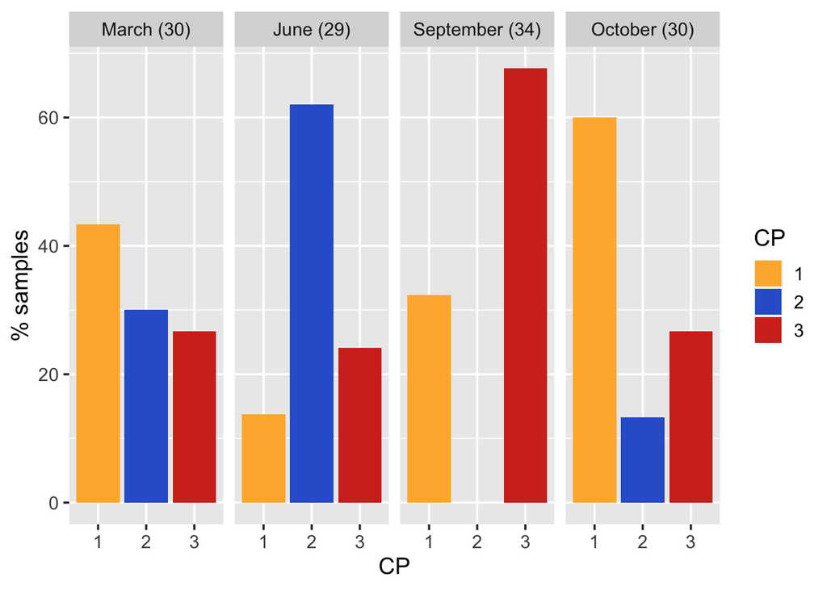

```r
plot_mo <- subset_samples(ps_gingival_orig, month_captured == "3" | month_captured == "6" | month_captured == "9" | month_captured == "10")
merged_table <- table((sample_data(plot_mo)$CP),(sample_data(plot_mo)$month_captured))
value <- prop.table(merged_table,margin=2)*100 # margin = 2 makes it such that you are looking at within a given month, X% of samples are CP1, Y% CP2, etc
# create a dataset
specie=c(rep("March (30)" , 3) , rep("June (29)" , 3) , rep("September (34)" , 3) , rep("October (30)" , 3) )
CP=rep(c("1" , "2" , "3") , 4)
data1=data.frame(specie,CP,value)
data1$specie<-factor(data1$specie, levels=c("March (30)", "June (29)", "September (34)", "October (30)") ) # this line makes sure the months are ordered chronologically rather than alphabetically
# Faceting
p <- ggplot(data1, aes(y=Freq, x=CP, fill=CP)) +
    ylab ("% samples") +
    geom_bar(position="dodge", stat="identity") +
    facet_grid(~specie) +
    scale_fill_manual(values=c("#ffb43a", "#3162d1", "#d33321")) +
    theme_gray(base_size = 14) # grey background
p
```